# Chapter5

smooshi

2018 M12 2

# Chapter 5

## Task 1

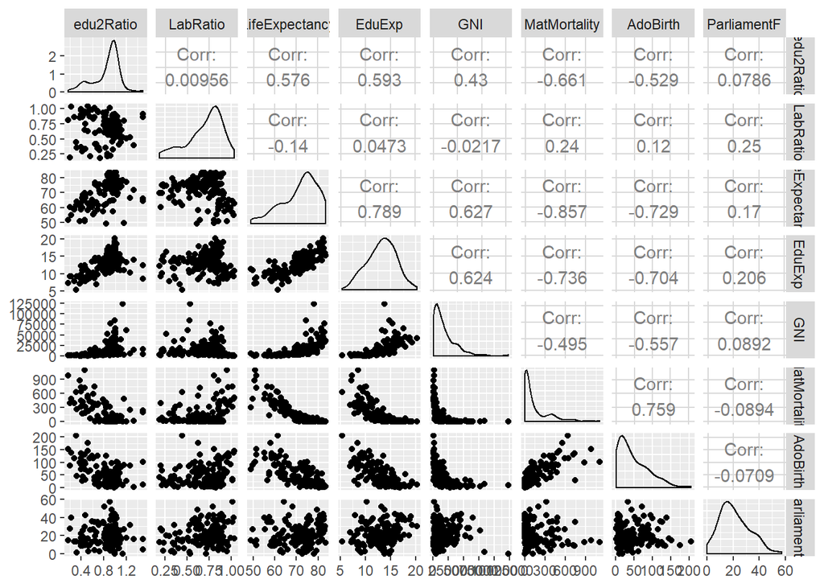

```r
human <- read.table("~/GitHub/IODS-project/data/human.csv", header = TRUE, row.names= 1, sep = ",")

# visualize the 'human_' variables
ggpairs(human)
```

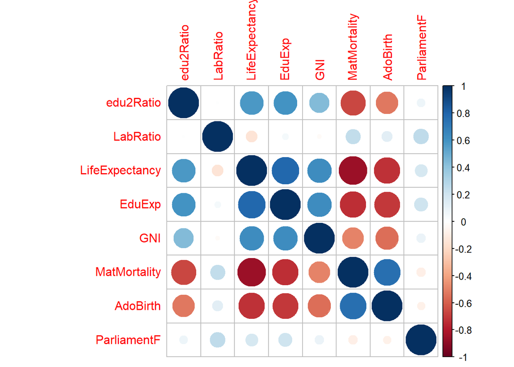

```r
# compute the correlation matrix and visualize it with corrplot
cor(human) %>% corrplot()
```

```r
summary(human)
```

```
##    edu2Ratio         LabRatio      LifeExpectancy      EduExp
##  Min.   :0.1717   Min.   :0.1857   Min.   :49.00   Min.   : 5.40
##  1st Qu.:0.7264   1st Qu.:0.5984   1st Qu.:66.30   1st Qu.:11.25
##  Median :0.9375   Median :0.7535   Median :74.20   Median :13.50
##  Mean   :0.8529   Mean   :0.7074   Mean   :71.65   Mean   :13.18
##  3rd Qu.:0.9968   3rd Qu.:0.8535   3rd Qu.:77.25   3rd Qu.:15.20
##  Max.   :1.4967   Max.   :1.0380   Max.   :83.50   Max.   :20.20
##       GNI          MatMortality       AdoBirth       ParliamentF
##  Min.   :   581   Min.   :   1.0   Min.   :  0.60   Min.   : 0.00
##  1st Qu.:  4198   1st Qu.:  11.5   1st Qu.: 12.65   1st Qu.:12.40
##  Median : 12040   Median :  49.0   Median : 33.60   Median :19.30
##  Mean   : 17628   Mean   : 149.1   Mean   : 47.16   Mean   :20.91
##  3rd Qu.: 24512   3rd Qu.: 190.0   3rd Qu.: 71.95   3rd Qu.:27.95
##  Max.   :123124   Max.   :1100.0   Max.   :204.80   Max.   :57.50
```

In general female education correlates slightly to moderately positively with “good things” like Life Expectancy and negatively with “bad things” like Maternal Mortality and child pregnancy. Maternal MOrtality in general is very low, but overrepresented in some countries. Maternal Mortality in Europe is generally < 10, but in the some African countries it is very high like Sierra Leone (max, 1100) and Chad (980). Many traits show this same pattern where majority of Western Countries are grouped around the peak and there’s a second smaller “bump” where Developing Countries are. In general most of these trains look good (as in life expectancy is a right tilted distribution, Adolescent birth rate is a left tilted distribution) except parlamentary representation that is left tilted (women are underrepresented in most countries).

## Task 2 : Principle Component Analysis

The original variables of data might contain too much information for representing the phenomenon of interest, so we have to reduce dimensions to “most essential dimensions”. We use “Principle component analysis” or PCA, it is an unsupervised method. PCA is sensitive to the relative scaling of the original features and assumes that features with larger viarance are more important that features with smaller variance. Data should be standardized before using PCA.

First Principle Component captures the maximum amount of variance from features in the original data.

Second Principle component is orthogonal to the first and captures maximum amount of variability left.

### Not standardized:

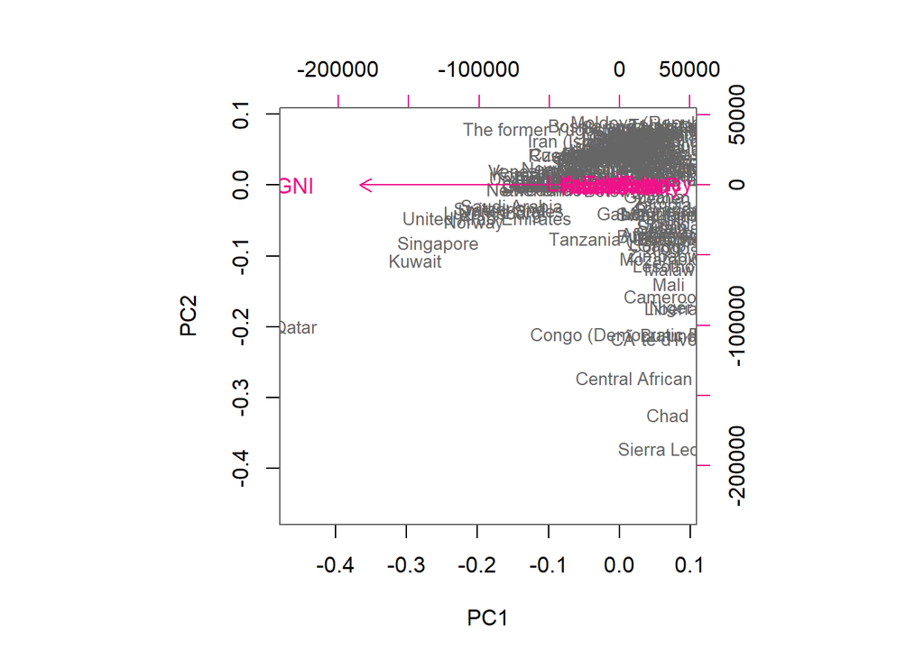

```r
#perform principal component analysis (with the SVD method)
pca_human <- prcomp(human)

# draw a biplot
biplot(pca_human, cex = c(0.8, 1), col = c("grey40", "deeppink2"))
```

This does not work at all… Standardization is very important. There is not much that can be interpreted here and there’s many errors. Arrows don’t seem to work and the only explaining thing is that GNI explains left grouping and all other variables group right. This is not the same as in corrplot, where GNI has a positive relationship with Life Expectancy and Education Expected Years… This plot doesn’t work.